# Random Forest Analysis with Juglans nigra microbiome

## R Packages

```r
library(doParallel)
library(foreach)
library(tidyverse)
library(ggplot2)
library(vegan)
library(reshape2)
library(phyloseq)
library(randomForest)
library(doBy)
library(plotrix)
library(ggpubr)
```

## Project Summary

This script performs a random forest classification (citation) on merged bacterial and fungal mothur data. It plots the results as a heatmap and barchart containing bootstrapped importance values for predicting where a sample came from based on its microbiome profile with a susbset of the most important OTUs as predictor variables. It also outputs a taxonomy table with the identity of those OTUs.

Memory and processor time issues were encountered with the newest version of randomForest. For this reason, the prunescale cutoff was set higher for soil to prevent a stack overflow. To deal with processing time issues, I used the packages “doParallel” and “foreach” to implement parallel processing of the bootstrap.

We start by loading in the data image containnig merged bacterial-fungal phyloseq object created in Make.RData.Mac.R

```r
load("R_Environments/Jnigra.microbiome.merged.WilliamsOnufrak.RData")
```

## Prepare data for analysis

First, we need to prune the data. There are a lot of rare taxa that will not be helpful in machine learning. Reducing noice from rare taxa will improve the efficiency of the random forest classification algorithm by allowing it to find solutions more quickly.

```r
# Prunescale is the minimum average number of reads across samples that will be retained.
# All OTUs that do not average > prunescale across samples will be dropped.
prunescale.shavings = 0.05

# Prune out rare OTUs by mean relative abundance set by prunescale
tax.mean.shavings <- taxa_sums(shavings.merge)/nsamples(shavings.merge) # average number of reads for each otu
sites.prune.shavings <- prune_taxa(tax.mean.shavings > prunescale.shavings, shavings.merge)
```

Next, we are going to format a dataframe of predictors (OTUs) and responses (States)

```r
# Make a dataframe of training data with OTUs as column and samples as rows
predictors.shavings <- t(otu_table(sites.prune.shavings))
dim(predictors.shavings)
```

```
## [1]   39 3215
```

```r
# Make one column for our outcome/response variable
response.shavings <- as.factor(sample_data(sites.prune.shavings)$State)

# Combine them into 1 data frame
rf.data.shavings <- data.frame(response.shavings, predictors.shavings)
```

## Conduct the analysis

There is stocasticity in the random forest analysis algorithm. To produce robust results, we bootstrapped our random forest analysis. Since random forest is computationally-intensive, we can speed this process up by parallelizing the analysis. This script implements parallel processing with the `doParallel` package.

```r
# Set a random seed
set.seed(579383)

# My computer has 8 processor cores - adjust parameter of the following command as needed/desired
registerDoParallel(8)
```

Next, we are going to run two loops and store the results of the random forest analysis. In the first loop we store the importance variables of the predictors. In the second, independent loop, we store the out of bag error rate, which is a measure of how often the final decision tree selected by the algorithm misclassified our data from a particular sample microbial community into the wrong state.

```r
# %dopar% implemented with foreach implements each loop call as an independent function call
# and then parallelizes all the function calls across the number of processers set above with
# registerDoParallel(). First, we need to set up a dataframe to store each bootstrap RF result.
boot.imp.s <- data.frame(predictors=NULL, Try=NULL, MeanDecreaseGini=NULL)
boot.imp.s <- foreach (Try=1:100, .combine=rbind) %dopar% {

  shavings.classify <- randomForest(response.shavings ~., data = rf.data.shavings, ntree = 500, proximity=T, mtry=200)
  print(shavings.classify)

  # Make a data frame with predictor names and their importance
  imp.s <- importance(shavings.classify)
  imp.s <- data.frame(predictors = rownames(imp.s), imp.s)

  cbind(imp.s, data.frame(Try=Try)) #)

}

# Same (and independent) as above but this time we are storing results from the
# out-of-bag error rates, so we car report the correct-incorrect classification
# rate for each group, and what types of misclassifications were made.
boot.oob <- NULL
boot.oob <- foreach (Try=1:100, .combine=rbind) %dopar% {

  shavings.classify <- randomForest(response.shavings ~., data = rf.data.shavings, ntree = 500, proximity=T, mtry=200)
  print(shavings.classify)

  # Make a data frame with predictor names and their importance
  imp.s <- importance(shavings.classify)
  imp.s <- data.frame(predictors = rownames(imp.s), imp.s)

  c(boot.oob, shavings.classify$err.rate[500,1])
}
```

## Display and visualize results

First we want to see the mean and standard deviation out-of-bag error rate.

```r
# Look at the results
mean(boot.oob)
```

```
## [1] 0.01435897
```

```r
sd(boot.oob)
```

```
## [1] 0.01279199
```

```r
range(boot.oob)
```

```
## [1] 0.00000000 0.02564103
```

Next, we want to look at the predictors. So we are going to make a bootstrap data frame with the `summaryBy` function, and then arrange the predictors by order of the average importance value (`MeanDecreaseGini`, or the Gini index, the amount the decision tree degrades in purity when you remove the predictor). The we are going to look at the taxonomic information for those predictor OTUs and we are going to output them into a nice `.csv` file.

```r
# Create a dataframe with summary statistics from our bootstrap runs
summary.boot.s <- summaryBy(MeanDecreaseGini ~ predictors, data= boot.imp.s, FUN = c(mean, sd, std.error))

# Look at it
head(summary.boot.s)
```

```
##   predictors MeanDecreaseGini.mean MeanDecreaseGini.sd
## 1   Botu0001           0.004539461         0.006595892
## 2   Botu0002           0.002523216         0.004666331
## 3   Botu0003           0.141983430         0.057595473
## 4   Botu0004           0.158574771         0.064935074
## 5   Botu0005           0.142462813         0.058001812
## 6   Botu0006           0.073233123         0.042390084
##   MeanDecreaseGini.std.error
## 1               0.0006595892
## 2               0.0004666331
## 3               0.0057595473
## 4               0.0064935074
## 5               0.0058001812
## 6               0.0042390084
```

```r
# Order the predictor levels by importance
imp.s.sort <- arrange(summary.boot.s, desc(MeanDecreaseGini.mean))
imp.s.sort$predictors <- factor(imp.s.sort$predictors, levels = imp.s.sort$predictors)

# Select the top 40 predictors
imp.s.40 <- imp.s.sort[1:40, ]

# What are those OTUs?
# otunames.s = otunames of predictors
# r.s = A logical containing which rows from phyloseq object were recovered as top 40 predictors
otunames.s <- imp.s.40$predictors
r.s <- rownames(tax_table(shavings.merge)) %in% otunames.s

# Use r.s to pull out the taxonomic information for those OTUS in otunames.s
t.table <- as.data.frame(tax_table(shavings.merge)[r.s, ])

write.csv(t.table, "Results/RF.shavings.t.table.csv", quote=F,row.names=T)
```

For our graphic, we want a heatmap with taxonomic names on the left on the y axis, the samples on the x-axis, and a vertical bar chart with mean and standard deviation importance values from our bootstrapping. We also want to make sure the taxonomic names are useful and make sense, and we want to organize the heatmap so we can see clear differences between states that were picked up in the random forest microbial ‘signature’. To accomplish this, we will need to get creative with our data wrangling.

```r
# Reformat the taxonomic names and paste them to OTU names for axis labels
# (highest determined taxonomic rate, get rid of special characters, etc.)
axislabels <- with(t.table, paste(rownames(t.table), gsub("[sgfocp]__","",Genus,perl=T) %>% gsub("_"," ",.,perl=T) %>% gsub("[\\s]?(unclassified|ge)[\\s]?","",.,perl=T)))
names(axislabels) <- rownames(t.table)
i <- grep("(uncultured)|([01234567890-]$)+", axislabels, perl=T)
axislabels[i]<-paste(names(axislabels)[i], t.table$Family[i])

# Now we sum the abundance of each OTU by state so we can order the
# RF predictor OTUs by which state they were most abundant in, followed
# by their importance value. This makes the heatmap easier to interpret.
sums<-summaryBy(. ~ response.shavings, data = rf.data.shavings[, c('response.shavings', as.character(otunames.s))], FUN = sum, keep.names = T)
state.organize <- sapply(as.character(otunames.s), FUN = function(x) which.max(sums[,x]))

# hm is a dataframe of the abundance of the predictors, standardized and log transformed
hm <- rf.data.shavings[,as.character(otunames.s)] %>% decostand(method='max', MARGIN=2) %>% decostand(method='log')
hm$sample <- gsub('_',' ',sample_data(shavings.merge)[rownames(hm),'New.names']$New.names)
```

Use the `melt()` function to turns the ordered dataframe into a new data frame that represents the value in each column as a new row so that each row represents an individual observation. This creates a dataframe with columnes for tree, the otu, and its standardized transformed abundance in that tree for the heatmap.

```r
hm.melt <- melt(hm[c(order(state.organize), 41)])
names(hm.melt) <- c("Tree","Taxon","StandardizedAbundance")
```

To plot everything, we are first going to separately make the heatmap with the OTU names on the y axis labels, then make the bargraph, and stick them together.

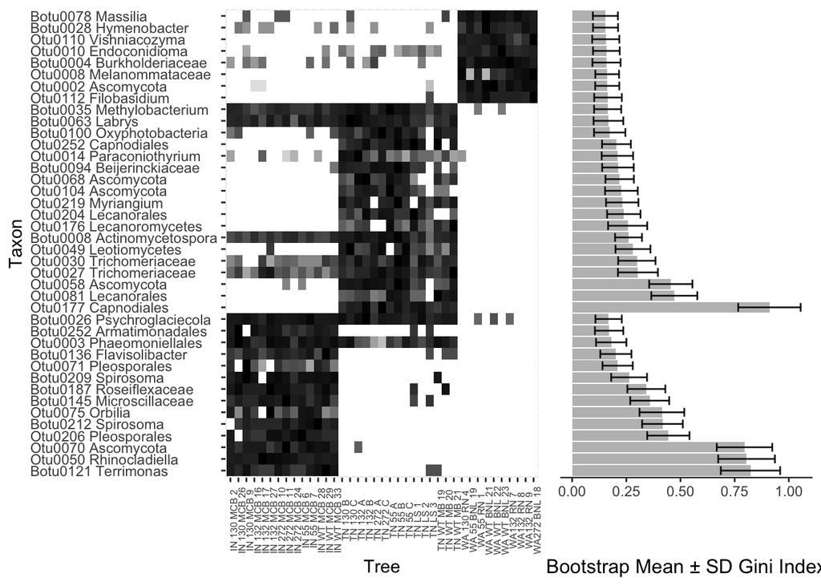

```r
# Turn predictors into a factor (re-ordered the same as the hm.melt object so they match up)
imp.s.40$predictors <- factor(imp.s.40$predictors, levels(imp.s.40$predictors)[order(state.organize)])

# Creat the heatmap with the taxon names and OTUs
plot1 <- ggplot(hm.melt, aes(x=Tree, y=Taxon, fill=StandardizedAbundance)) + geom_tile() + scale_fill_gradient(low="white", high="black") + theme(axis.text.x = element_text(angle=90, size=6), legend.position = "none", axis.text.y = element_text(hjust=0))  + scale_y_discrete(labels=axislabels)
g1 <- ggplotGrob(plot1)

# Creat the bargraph
plot2 <- ggplot(imp.s.40, aes(x = predictors, y = MeanDecreaseGini.mean)) +
  geom_bar(stat = "identity", fill = "grey") +
  ylab("Bootstrap Mean \u00b1 SD Gini Index") +
  theme_bw() +
  geom_errorbar( aes(x=predictors, ymin=MeanDecreaseGini.mean-MeanDecreaseGini.sd, ymax=MeanDecreaseGini.mean+MeanDecreaseGini.sd), width=0.75, alpha=0.9, size=0.5) +
  coord_flip() + theme(axis.title.y=element_blank(),
        axis.text.y=element_blank(),
        axis.ticks.y=element_blank(),
        axis.line.x=element_line(),
        axis.title=element_text(size=12),
            plot.background = element_rect(fill = NULL,colour = NA),
            panel.border = element_blank(),
            panel.grid = element_blank())
g2 <- ggplotGrob(plot2)

# Put them togethers
ggarrange(g1, g2, align='h', nrow=1, ncol=2, widths=c(4,2))
```

```r
# If we wanted, we could output them to a nice PDF

#pdf(paste("Figures/Caulosphere.RF", Sys.time(), ".pdf"), 9,6)
#ggarrange(g1, g2, align='h', nrow=1, ncol=2, widths=c(4,2))
#dev.off()
```